# Lyon Housing Statistical Report

Vaneh Azaryan & Amirhossein Aminimanesh

2022

# Attach data

First we load the dataset into R, define the categorical variables and assign appropriate labels to each category.

```r
data=read.csv(file.choose())
data$type_purchase <- factor(data$type_purchase,labels=c("ancien","VEFA"))
data$type_property <- factor(data$type_property,labels=c("appartement","maison"))
data$rooms_count <- factor(data$rooms_count,labels=1:6)
data$parkings_count <- factor(data$parkings_count,labels=0:3)
data$district <- factor(data$district,labels=c('Lyon 1er Arrondissement' , 'Lyon 2e Arrondissement' , 'Lyon 3e Arrondissement' ,
                                               'Lyon 4e Arrondissement' , 'Lyon 5e Arrondissement' , 'Lyon 6e Arrondissement' ,
                                               'Lyon 7e Arrondissement' , 'Lyon 8e Arrondissement' , 'Lyon 9e Arrondissement' , 'Villeurbanne'))
```

To have an overall sense of the data and see if it’s loaded correctly, we take a look at the first 6 observations of the data.

```r
knitr::kable(head(data) , caption = "First 6 observations of the data")
```

First 6 observations of the data

| date_transaction | type_purchase | type_property | rooms_count | surface_housing | surface_effective_usable | surface_terrain | parkings_count | price | address | district | latitude | longitude | date_construction |
| --- | --- | --- | --- | --- | --- | --- | --- | --- | --- | --- | --- | --- | --- |
| 19/10/31 | ancien | maison | 5 | 100 | NA | 247 | 0 | 530000 | 6 PAS DES ANTONINS | Villeurbanne | 45.78167 | 4.879333 | 03/06/11 11:38 |
| 18/11/26 | ancien | maison | 2 | 52 | NA | 156 | 0 | 328550 | 12 RUE DU LUIZET | Villeurbanne | 45.78324 | 4.884683 | 03/06/11 11:38 |
| 16/08/04 | ancien | appartement | 1 | 28 | 28.2 | 0 | 1 | 42500 | 4 RUE DE L ESPOIR | Villeurbanne | 45.78149 | 4.883474 | 03/06/11 11:38 |
| 16/11/18 | ancien | appartement | 3 | 67 | 66.3 | 0 | 1 | 180900 | 6 RUE DE L ESPOIR | Villeurbanne | 45.78149 | 4.883474 | 03/06/11 11:38 |
| 16/12/16 | ancien | appartement | 1 | 28 | NA | 0 | 1 | 97000 | 163 AV ROGER SALENGRO | Villeurbanne | 45.78149 | 4.883474 | 03/06/11 11:38 |
| 17/01/06 | ancien | appartement | 2 | 42 | NA | 0 | 1 | 112000 | 163 AV ROGER SALENGRO | Villeurbanne | 45.78149 | 4.883474 | 03/06/11 11:38 |

## Descriptive statistics

Now we check some of its characteristics such as minimum, maximum, mean, 1st 2nd and 3rd quartile for continuous variables and frequency tables for categorical variables. Also the number of missing values for each variable is shown in the table. For continues variables a tiny representation of its histogram has been shown on the right-hand of the output.

```r
library(skimr)
skim(data)
```

Data summary

| Name | data |
| --- | --- |
| Number of rows | 40516 |
| Number of columns | 14 |
| _______________________ |  |
| Column type frequency: |  |
| character | 3 |
| factor | 5 |
| numeric | 6 |
| ________________________ |  |
| Group variables | None |

**Variable type: character**

| skim_variable | n_missing | complete_rate | min | max | empty | n_unique | whitespace |
| --- | --- | --- | --- | --- | --- | --- | --- |
| date_transaction | 0 | 1 | 8 | 8 | 0 | 1396 | 0 |
| address | 0 | 1 | 0 | 33 | 337 | 11295 | 0 |
| date_construction | 0 | 1 | 13 | 14 | 0 | 826 | 0 |

**Variable type: factor**

| skim_variable | n_missing | complete_rate | ordered | n_unique | top_counts |
| --- | --- | --- | --- | --- | --- |
| type_purchase | 0 | 1 | FALSE | 2 | anc: 35562, VEF: 4954 |
| type_property | 0 | 1 | FALSE | 2 | app: 39832, mai: 684 |
| rooms_count | 0 | 1 | FALSE | 6 | 3: 12615, 2: 10966, 4: 7805, 1: 6023 |
| parkings_count | 0 | 1 | FALSE | 4 | 1: 19910, 0: 18512, 2: 1910, 3: 184 |
| district | 0 | 1 | FALSE | 10 | Vil: 10330, Lyo: 5974, Lyo: 5289, Lyo: 4626 |

**Variable type: numeric**

| skim_variable | n_missing | complete_rate | mean | sd | p0 | p25 | p50 | p75 | p100 | hist |
| --- | --- | --- | --- | --- | --- | --- | --- | --- | --- | --- |
| surface_housing | 0 | 1.00 | 65.24 | 28.22 | 20.00 | 45.00 | 63.00 | 80.00 | 300.00 | ▇▃▁▁▁ |
| surface_effective_usable | 14491 | 0.64 | 63.53 | 26.39 | 2.81 | 44.70 | 62.80 | 78.11 | 270.67 | ▆▇▁▁▁ |
| surface_terrain | 0 | 1.00 | 3.76 | 36.45 | 0.00 | 0.00 | 0.00 | 0.00 | 944.00 | ▇▁▁▁▁ |
| price | 0 | 1.00 | 255758.91 | 154493.32 | 24000.00 | 155272.50 | 220000.00 | 309000.00 | 2780000.00 | ▇▁▁▁▁ |
| latitude | 143 | 1.00 | 45.76 | 0.02 | 45.72 | 45.75 | 45.76 | 45.77 | 45.81 | ▂▆▇▃▁ |
| longitude | 143 | 1.00 | 4.85 | 0.03 | 4.77 | 4.83 | 4.85 | 4.88 | 4.92 | ▂▅▆▇▂ |

# Correlation

Here, we tend to compute a correlation matrix, a matrix of correlation p-value and Visualize the correlation matrix. Positive values mean that two variables are positively correlated and negative values mean that they’re negatively correlated. These values are summarized and visualized in the diagram. Also p-values show whether the correlation has been statistically significant or it was just a matter of sampling.

```r
numericColumn = c(4,5,7:9 , 12,13)
d1 = data[complete.cases(data[,numericColumn]),numericColumn]
d1=sapply(d1 , as.numeric )
#install.packages("ggcorrplot")
library(ggcorrplot)
```

## Correlation matrix

```r
# Compute a correlation matrix
corr <- cor(d1)
knitr::kable(as.data.frame(corr), caption = "Correlation Matrix (rows and columns represent variables with the correlation calculated in the table)")
```

Correlation Matrix (rows and columns represent variables with the correlation calculated in the table)

|  | rooms_count | surface_housing | surface_terrain | parkings_count | price | latitude | longitude |
| --- | --- | --- | --- | --- | --- | --- | --- |
| rooms_count | 1.0000000 | 0.8384097 | 0.1416700 | 0.2655705 | 0.5569981 | 0.0504708 | -0.0307568 |
| surface_housing | 0.8384097 | 1.0000000 | 0.1774102 | 0.2175994 | 0.7475617 | 0.0768332 | -0.0844437 |
| surface_terrain | 0.1416700 | 0.1774102 | 1.0000000 | -0.0861841 | 0.3339734 | -0.0158916 | 0.0588497 |
| parkings_count | 0.2655705 | 0.2175994 | -0.0861841 | 1.0000000 | 0.1881447 | -0.0917025 | 0.0686549 |
| price | 0.5569981 | 0.7475617 | 0.3339734 | 0.1881447 | 1.0000000 | 0.0535578 | -0.1147147 |
| latitude | 0.0504708 | 0.0768332 | -0.0158916 | -0.0917025 | 0.0535578 | 1.0000000 | -0.1289404 |
| longitude | -0.0307568 | -0.0844437 | 0.0588497 | 0.0686549 | -0.1147147 | -0.1289404 | 1.0000000 |

## Correlation p-values

```r
# Compute a matrix of correlation p-value
p.mat <- cor_pmat(d1)
knitr::kable(as.data.frame(p.mat) , caption = "Matrix of Correlation p-value" )
```

Matrix of Correlation p-value

|  | rooms_count | surface_housing | surface_terrain | parkings_count | price | latitude | longitude |
| --- | --- | --- | --- | --- | --- | --- | --- |
| rooms_count | 0 | 0 | 0.0000000 | 0 | 0 | 0.0000000 | 0 |
| surface_housing | 0 | 0 | 0.0000000 | 0 | 0 | 0.0000000 | 0 |
| surface_terrain | 0 | 0 | 0.0000000 | 0 | 0 | 0.0014071 | 0 |
| parkings_count | 0 | 0 | 0.0000000 | 0 | 0 | 0.0000000 | 0 |
| price | 0 | 0 | 0.0000000 | 0 | 0 | 0.0000000 | 0 |
| latitude | 0 | 0 | 0.0014071 | 0 | 0 | 0.0000000 | 0 |
| longitude | 0 | 0 | 0.0000000 | 0 | 0 | 0.0000000 | 0 |

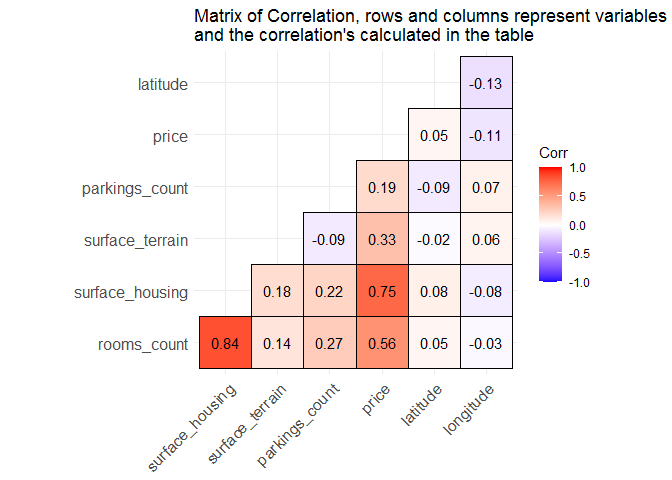

```r
# Visualize the correlation matrix
ggcorrplot(corr, type = "lower", outline.col = "black",lab=TRUE , title  = "Matrix of Correlation, rows and columns represent variables \nand the correlation's calculated in the table")
```

## Pairwise scatterplot

Next we draw the matrix of pairwise scatter plots. In each plot we’ve to check the name of the variables corresponding to it, to find the relevant plot.

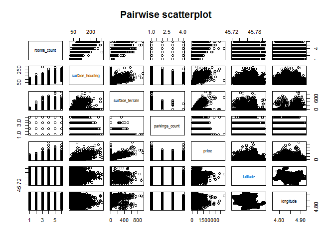

```r
pairs(data[numericColumn] , main = "Pairwise scatterplot ")
```

# Plots

## Histogram for Continues Variables

First we draw plot of frequency for each continues variable ordered as latitude, longitude, price, surface_effective_usable, surface_housing and surface_terrain.

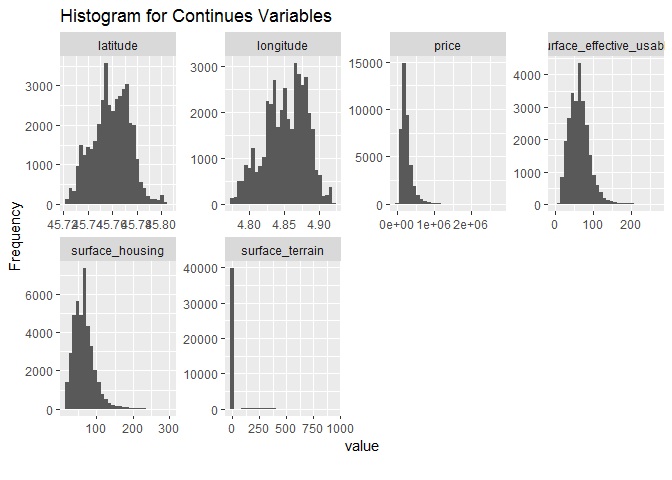

```r
library("ggplot2")
#install.packages("DataExplorer")
library(DataExplorer)
plot_histogram(data , title = "Histogram for Continues Variables")
```

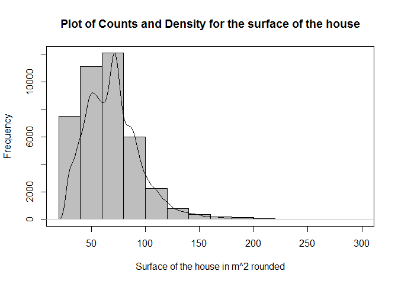

```r
#########################
##### Surface housing
hist(data$surface_housing , xlab = 'Surface of the house in m^2 rounded' , col="grey", main = 'Plot of Counts and Density for the surface of the house')
par(new=T)
plot(density(data$surface_housing) , xlab = '' , ylab = '' , xaxt='n' , yaxt='n' , main = '')
```

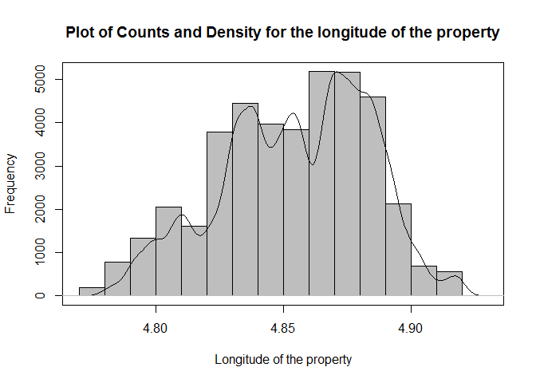

```r
##### Longitude
hist(data$longitude , xlab = 'Longitude of the property' , col="grey", main = 'Plot of Counts and Density for the longitude of the property')
par(new=T)
plot(density(na.omit(data$longitude)) , xlab = '' , ylab = '' , xaxt='n' , yaxt='n' , main = '')
```

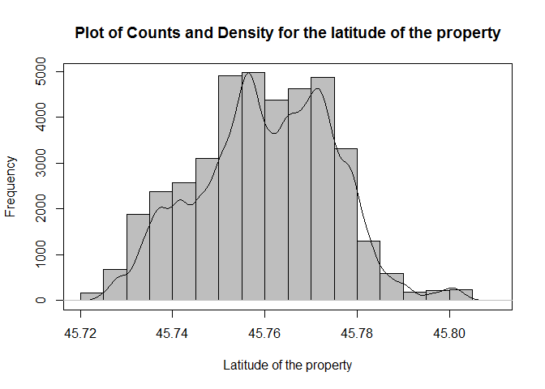

```r
##### Latitude
hist(data$latitude , xlab = 'Latitude of the property' , col="grey", main = 'Plot of Counts and Density for the latitude of the property')
par(new=T)
plot(density(na.omit(data$latitude)) , xlab = '' , ylab = '' , xaxt='n' , yaxt='n' , main = '')
```

[figure not shown]

```r
##### Price
hist(data$latitude , xlab = 'Price' , col="grey", main = 'Plot of Counts and Density for the selling price of the property in Euro')
par(new=T)
plot(density(na.omit(data$latitude)) , xlab = '' , ylab = '' , xaxt='n' , yaxt='n' , main = '')
```

[figure not shown]

```r
##### Surface Terrain
hist(data$latitude , xlab = 'Surface of the terrain' , col="grey", main = 'Plot of Counts and Density for the surface of the terrain in m^2')
par(new=T)
plot(density(na.omit(data$latitude)) , xlab = '' , ylab = '' , xaxt='n' , yaxt='n' , main = '')
```

## Frequency Plots for Categorical Variables

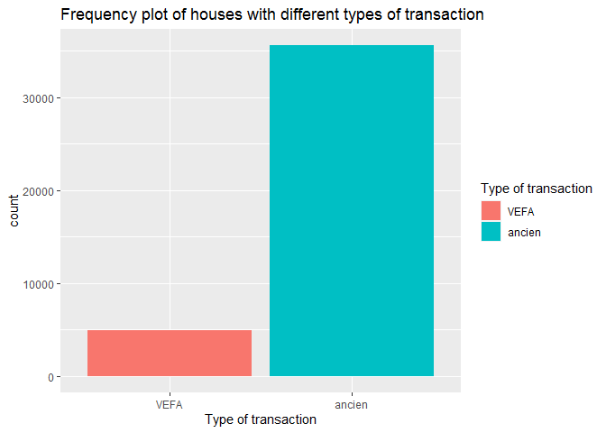

```r
compute <- function(x) {
    freq <- table(x)
    factor(x, levels = names(sort(freq)))
}

ggplot(data, aes(x = compute(type_purchase))) +
    geom_bar(aes(fill = compute(type_purchase))) +
    xlab("Type of transaction")+
    scale_fill_discrete(name = "Type of transaction") + ggtitle("Frequency plot of houses with different types of transaction")
```

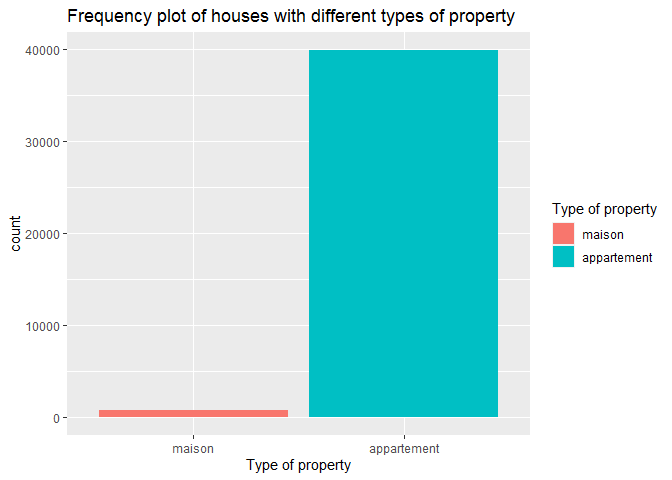

```r
ggplot(data, aes(x = compute(type_property))) +
    geom_bar(aes(fill = compute(type_property))) +
    xlab("Type of property")+
    scale_fill_discrete(name = "Type of property")+ ggtitle("Frequency plot of houses with different types of property")
```

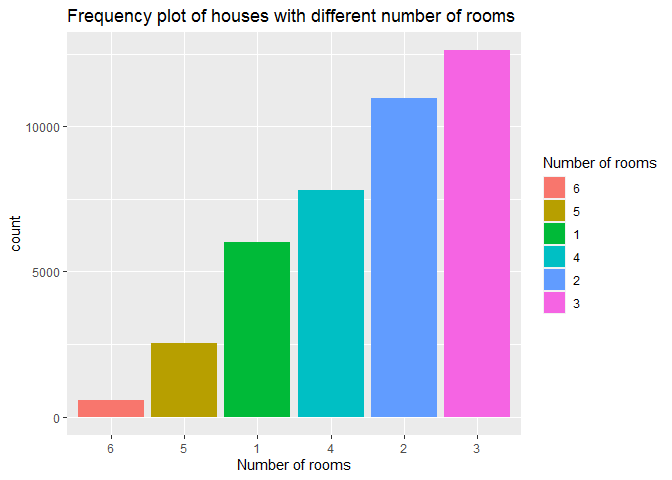

```r
ggplot(data, aes(x = compute(rooms_count))) +
    geom_bar(aes(fill = compute(rooms_count))) +
    xlab("Number of rooms")+
    scale_fill_discrete(name = "Number of rooms")+ ggtitle("Frequency plot of houses with different number of rooms")
```

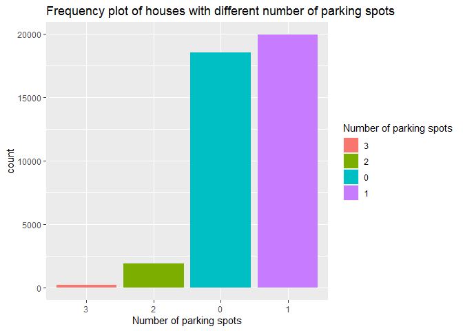

```r
ggplot(data, aes(x = compute(parkings_count))) +
    geom_bar(aes(fill = compute(parkings_count))) +
    xlab("Number of parking spots")+
    scale_fill_discrete(name = "Number of parking spots")+ ggtitle("Frequency plot of houses with different number of parking spots")
```

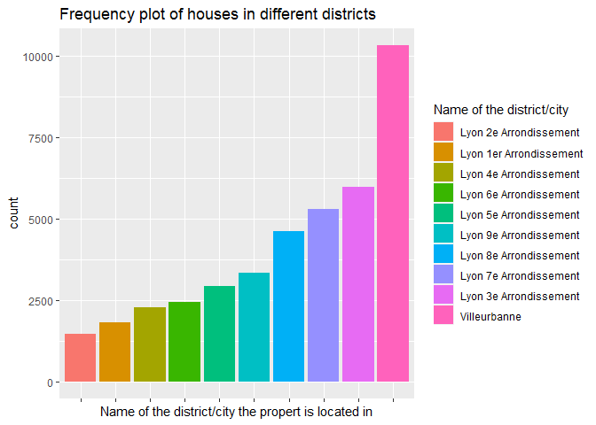

```r
ggplot(data, aes(x = compute(district))) +
    geom_bar(aes(fill = compute(district))) +
    xlab("Name of the district/city the propert is located in")+
    scale_fill_discrete(name = "Name of the district/city")+
    theme(axis.text.x = element_blank())+ ggtitle("Frequency plot of houses in different districts")
```

## Box plot

Next we consider each of these continues variables in different price bands. These plots give us a sense about the dispersion of the price over different values of each variable. For example prices are higher for houses in the range of 4.835 and 4.87 based on the longitude with the median about 4.85.

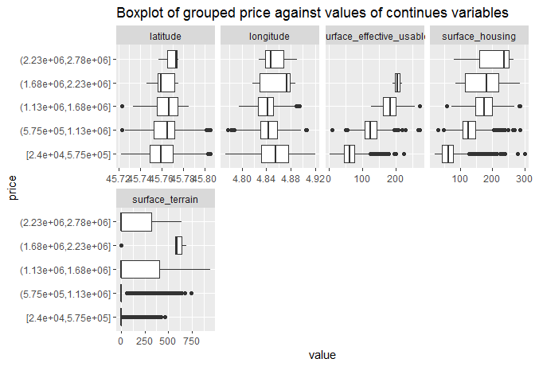

```r
plot_boxplot(data, by ="price" , title = "Boxplot of grouped price against values of continues variables")
```

After that, we check for the different levels of room counts based on the values of continues variables. For example, we realize that room counts are almost independent of the latitude and longitude, since no matter the number of the rooms the latitude and longitude change very slightly. Outliers, which are values far away from other values, are also shown in red.

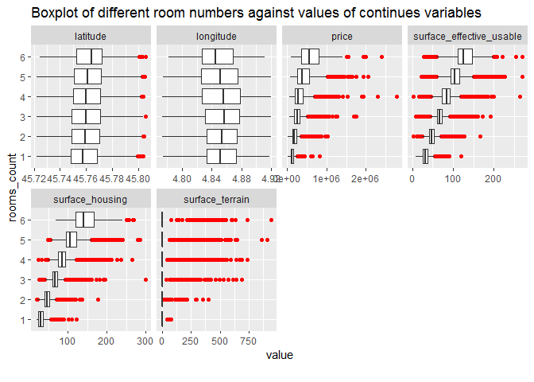

```r
plot_boxplot(data, by ="rooms_count",geom_boxplot_args = list("outlier.color" = "red") , title = "Boxplot of different room numbers against values of continues variables")
```

It’s possible to draw the corresponding plots for levels of other categorical variables based on the values of continues variables. Likewise, outliers are shown in red. The interpretation is the same as before.

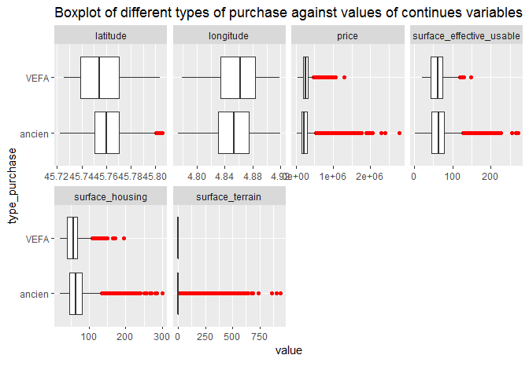

```r
plot_boxplot(data, by ="type_purchase",geom_boxplot_args = list("outlier.color" = "red") , title = "Boxplot of different types of purchase against values of continues variables")
```

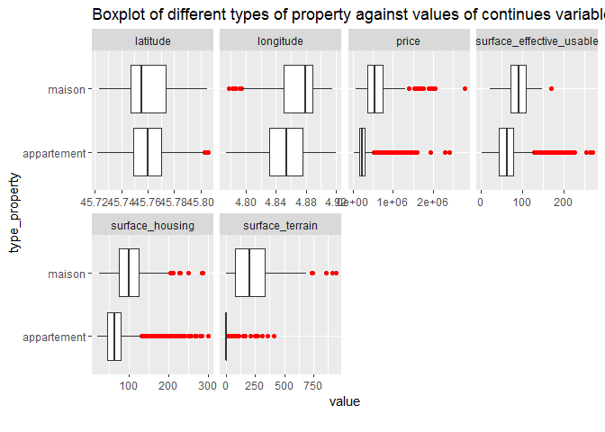

```r
plot_boxplot(data, by ="type_property",geom_boxplot_args = list("outlier.color" = "red") , title = "Boxplot of different types of property against values of continues variables")
```

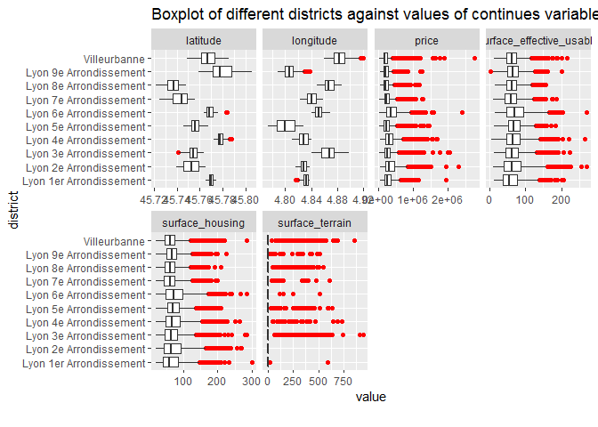

```r
plot_boxplot(data, by ="district",geom_boxplot_args = list("outlier.color" = "red"), title = "Boxplot of different districts against values of continues variables")
```

Now we check about which district has higher prices in overall. What we get is that ‘Lyon 6e Arrondissement’ has higher prices compared to the others and ‘Villeurbanne’ has the least prices.

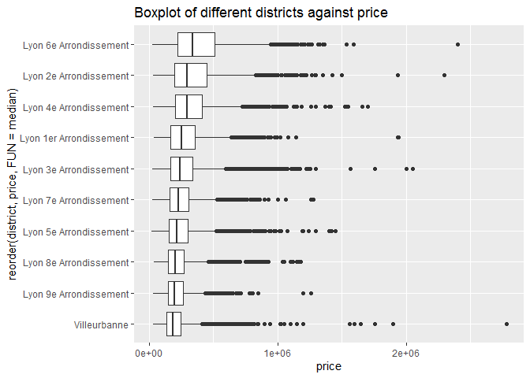

```r
#####################
ggplot(data = data) +
  geom_boxplot(mapping = aes(x = reorder(district, price, FUN = median), y = price)) +
  coord_flip()+ ggtitle("Boxplot of different districts against price")
```

We check other categorical variables in comparison to the price. Results are the following: In the first plot, as the number of rooms increases, the price also increases. In the second plot, it’s obvious that maison type of the building is higher in price. In the third plot, it’s seen that prices don’t differ much whether they’re of the type ancien or VEFA.

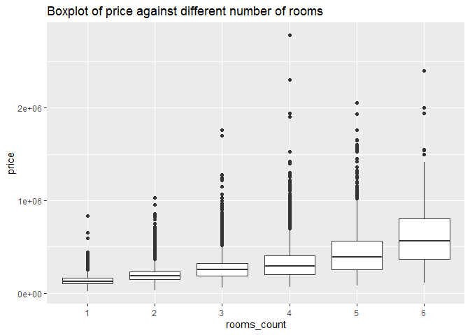

```r
ggplot(data = data, mapping = aes(x = rooms_count, y = price)) +
  geom_boxplot()+ ggtitle("Boxplot of price against different number of rooms")
```

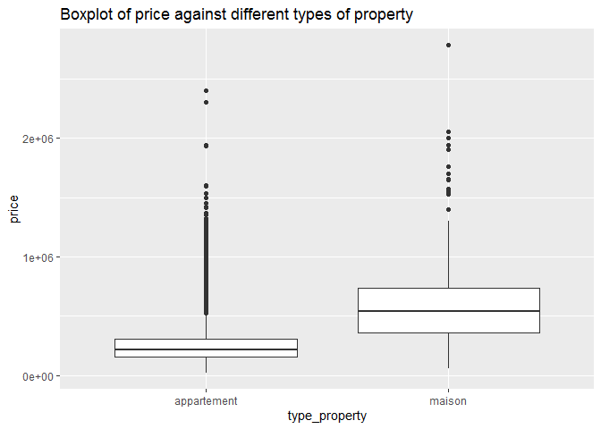

```r
ggplot(data = data, mapping = aes(x = type_property, y = price)) +
  geom_boxplot()+ ggtitle("Boxplot of price against different types of property")
```

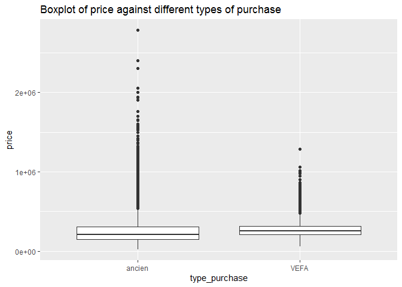

```r
ggplot(data = data, mapping = aes(x = type_purchase, y = price)) +
  geom_boxplot()+ ggtitle("Boxplot of price against different types of purchase")
```

We now consider the case where we investigate the year in which the building has been sold and look at how prices have changes over time. First, number of buildings sold in each year is calculated:

```r
#######################group by year of transaction
library(tidyr)
df=strsplit(as.character((data$date_transaction)),c('/'))
dates= data.frame(matrix(unlist(df), nrow=length(df), byrow=TRUE))
y=data.frame( year=as.factor(dates$X1))


knitr::kable((table(y)) , caption = "Frequency of houses sold in each year")
```

Frequency of houses sold in each year

| y | Freq |
| --- | --- |
| 16 | 4357 |
| 17 | 10061 |
| 18 | 8687 |
| 19 | 8497 |
| 20 | 6575 |
| 21 | 2339 |

Next, we check how prices of these houses have changed over time.

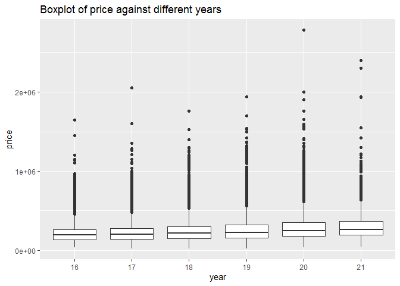

```r
df_yp=data.frame(year=y,price=data$price)

ggplot(data = df_yp, mapping = aes(x =year, y = price)) +
  geom_boxplot()+ ggtitle("Boxplot of price against different years")
```

As can be seen, prices have gone up over the years and it’s an indicator of the inflation.

Finally, we check price for different room counts, grouped by type of property.

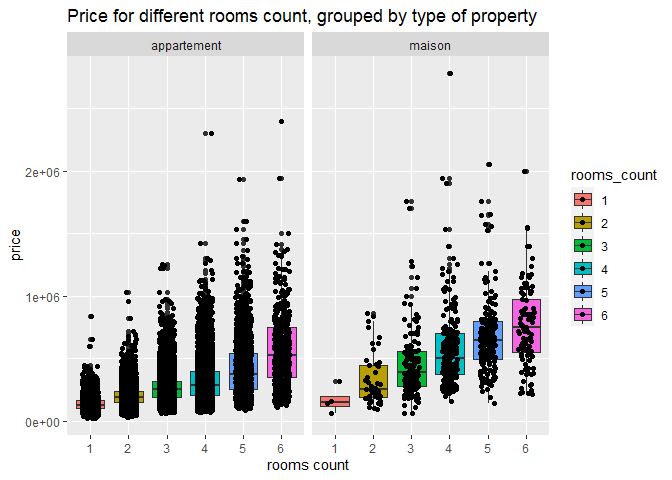

```r
#############################
ggplot(data = data, aes(x=rooms_count,y=price, fill=rooms_count)) +
  geom_boxplot()+
  geom_jitter(shape=16, position=position_jitter(0.2))+
  labs(title = 'Price for different rooms count, grouped by type of property',
       y='price',x='rooms count')+
  facet_wrap(~type_property,nrow = 1)
```

What we get from these two plot is the fact that maison type of the house seems to have higher prices in overall since each box in the maison type has a higher value compared to the corresponding box in the apartment type. Moreover, the more the number of rooms, the higher the price, which makes sense.

It’s also possible to check the price for different type of purchase, grouped by year of transaction.

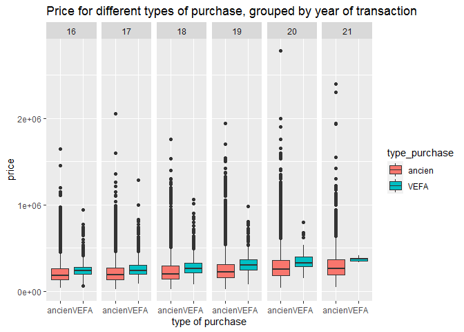

```r
##########################################price for different type of purchase grouped by year of transaction

df_yp=data.frame(year=y,price=data$price,type_purchase=data$type_purchase)
ggplot(data =df_yp , aes(x=type_purchase,y=price, fill=type_purchase )) +
  geom_boxplot()+
  labs(title = 'Price for different types of purchase, grouped by year of transaction',
       y='price',x='type of purchase')+
  facet_wrap( ~ year,nrow = 1)
```

As can be seen, prices for both types of building have gone up over years (Blue and pink boxes rise in Y axis as year increases). Also buildings of type VEFA tend to have higher prices compared to ancien type in each year of the years interval.

Moreover, one can check the prices in different districts, grouped by year of transaction.

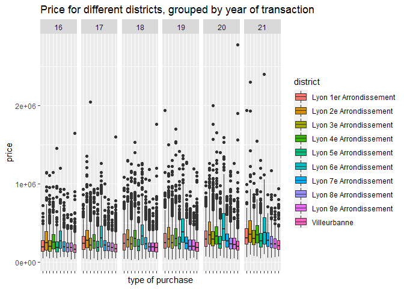

```r
##########################################price in different districts grouped by year of transaction
df_yp=data.frame(year=y,price=data$price,district=data$district)
ggplot(data =df_yp , aes(x=district,y=price, fill=district )) +
  geom_boxplot()+
  labs(title = 'Price for different districts, grouped by year of transaction',
       y='price',x='type of purchase')+
  facet_wrap( ~ year,nrow = 1)+
  theme(axis.text.x = element_blank())
```

# ANOVA

## Finding the best-fit model

Now we fit ANOVA and look for the best model based on some criteria. Here the criteria is the AIC value. The lower the value, the better the model.

```r
#install.packages(c( "ggpubr", "tidyverse", "broom", "AICcmodavg"))
library("sjPlot")
library(ggpubr)
library(tidyverse)
library(broom)
library(AICcmodavg)


model=NULL
vars = c("type_purchase","type_property","rooms_count","parkings_count","district")

for(i in 1:length(vars)){
  xx = combn(vars,i)
  if(is.null(dim(xx))){
    fla = paste("price ~ ", paste(xx, collapse="+"))
    model[[length(model)+1]]=aov(as.formula(fla),data=data)
  } else {
    for(j in 1:dim(xx)[2]){
      fla = paste("price ~ ", paste(xx[1:dim(xx)[1],j], collapse="+"))
      model[[length(model)+1]]=aov(as.formula(fla),data=data)
    }
  }
}

aictab(model)
```

```
##
## Model selection based on AICc:
##
##        K    AICc Delta_AICc AICcWt Cum.Wt        LL
## Mod31 21 1053068       0.00      1      1 -526513.2
## Mod30 20 1053991     922.94      0      1 -526975.7
## Mod27 18 1054467    1398.93      0      1 -527215.7
## Mod23 17 1055859    2790.65      0      1 -527912.6
## Mod29 20 1056991    3922.99      0      1 -528475.7
## Mod20 17 1057762    4693.90      0      1 -528864.2
## Mod25 19 1057848    4779.92      0      1 -528905.2
## Mod14 16 1058928    5859.49      0      1 -529448.0
## Mod26 12 1064368   11299.88      0      1 -532172.2
## Mod22 11 1064699   11630.23      0      1 -532338.3
## Mod16  9 1064856   11787.57      0      1 -532419.0
## Mod10  8 1065252   12183.82      0      1 -532618.1
## Mod19 11 1066644   13575.85      0      1 -533311.2
## Mod13 10 1066970   13901.88      0      1 -533475.2
## Mod7   8 1067022   13953.45      0      1 -533502.9
## Mod3   7 1067351   14282.29      0      1 -533668.4
## Mod28 16 1068897   15828.90      0      1 -534432.7
## Mod24 15 1069068   15999.35      0      1 -534518.9
## Mod18 13 1073189   20120.23      0      1 -536581.3
## Mod12 12 1073745   20676.64      0      1 -536860.6
## Mod21 15 1074519   21450.38      0      1 -537244.4
## Mod15 14 1074640   21571.53      0      1 -537306.0
## Mod17  7 1077479   24410.85      0      1 -538732.7
## Mod11  6 1077490   24421.67      0      1 -538739.1
## Mod9  12 1077529   24460.85      0      1 -538752.7
## Mod5  11 1077914   24845.49      0      1 -538946.0
## Mod6   4 1079706   26637.85      0      1 -539849.2
## Mod2   3 1079817   26748.16      0      1 -539905.3
## Mod8   6 1081380   28311.80      0      1 -540684.1
## Mod4   5 1081385   28316.08      0      1 -540687.3
## Mod1   3 1083086   30017.51      0      1 -541540.0
```

Here the 31st model is chosen as the best with 21 variables included (including dummy variables for the levels of the categorical variables)

```r
model_best=aov(price ~type_purchase+type_property+rooms_count+parkings_count+district,data=data)
summary(model_best)
```

```
##                   Df    Sum Sq   Mean Sq F value Pr(>F)
## type_purchase      1 1.459e+12 1.459e+12   128.5 <2e-16 ***
## type_property      1 7.732e+13 7.732e+13  6808.7 <2e-16 ***
## rooms_count        5 2.727e+14 5.454e+13  4803.2 <2e-16 ***
## parkings_count     3 7.455e+12 2.485e+12   218.8 <2e-16 ***
## district           9 1.482e+14 1.647e+13  1450.0 <2e-16 ***
## Residuals      40496 4.599e+14 1.136e+10
## ---
## Signif. codes:  0 '***' 0.001 '**' 0.01 '*' 0.05 '.' 0.1 ' ' 1
```

The table above shows values of degrees of freedom, sum of squares, F-value and p-value. What’s obvious from these p-values, is that all these variables worth keeping in the model.

## Checking for homoscedasticity

Next we plot relevant plots for the chosen model. The plots are residuals vs fitted (shouldn’t have any trend and values should be spread in two parallel horizontal bands), QQ-plot (which residuals should follow the straight line in order for the residuals to have normal distribution, here they are skewed to the right) and two other plots.

```r
model_best=aov(price ~type_purchase+type_property+rooms_count+parkings_count+district,data=data)
summary(model_best)
```

```
##                   Df    Sum Sq   Mean Sq F value Pr(>F)
## type_purchase      1 1.459e+12 1.459e+12   128.5 <2e-16 ***
## type_property      1 7.732e+13 7.732e+13  6808.7 <2e-16 ***
## rooms_count        5 2.727e+14 5.454e+13  4803.2 <2e-16 ***
## parkings_count     3 7.455e+12 2.485e+12   218.8 <2e-16 ***
## district           9 1.482e+14 1.647e+13  1450.0 <2e-16 ***
## Residuals      40496 4.599e+14 1.136e+10
## ---
## Signif. codes:  0 '***' 0.001 '**' 0.01 '*' 0.05 '.' 0.1 ' ' 1
```

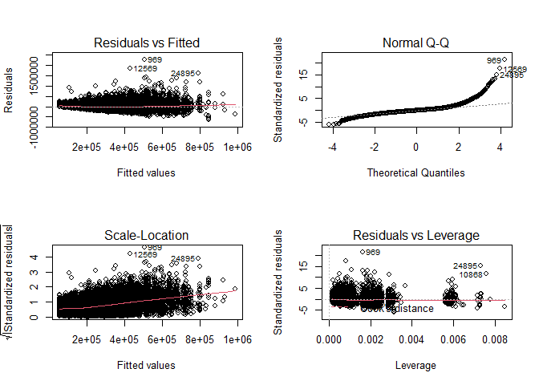

```r
par(mfrow=c(2,2))
plot(model_best)
```

## Doing a post-hoc test

We check which level of every categorical variable is different from the other in respect of the interest variable, price. All the levels of these categorical variables are different from another in respect of the price, except for two district ‘Lyon 4e Arrondissement-Lyon 1er Arrondissement’ and ‘Lyon 8e Arrondissement-Lyon 5e Arrondissement’ and with no or 1 parking spot. These results are consistent with the box plots for different districts based on price, drawn in the Plot section.

```r
tukey.two.way<-TukeyHSD(model_best)
tukey.two.way
```

```
##   Tukey multiple comparisons of means
##     95% family-wise confidence level
##
## Fit: aov(formula = price ~ type_purchase + type_property + rooms_count + parkings_count + district, data = data)
##
## $type_purchase
##                 diff      lwr      upr p adj
## VEFA-ancien 18319.85 15152.47 21487.24     0
##
## $type_property
##                        diff      lwr      upr p adj
## maison-appartement 338797.4 330743.1 346851.7     0
##
## $rooms_count
##          diff       lwr       upr p adj
## 2-1  59261.23  54390.84  64131.62     0
## 3-1 125124.60 120368.40 129880.80     0
## 4-1 179064.28 173855.96 184272.59     0
## 5-1 277273.36 270075.81 284470.90     0
## 6-1 410104.05 396901.41 423306.68     0
## 3-2  65863.37  61898.55  69828.20     0
## 4-2 119803.05 115305.84 124300.26     0
## 5-2 218012.13 211311.16 224713.11     0
## 6-2 350842.82 337904.20 363781.45     0
## 4-3  53939.68  49566.39  58312.96     0
## 5-3 152148.76 145530.32 158767.20     0
## 6-3 284979.45 272083.37 297875.52     0
## 5-4  98209.08  91258.62 105159.54     0
## 6-4 231039.77 217970.20 244109.35     0
## 6-5 132830.69 118848.85 146812.53     0
##
## $parkings_count
##           diff        lwr        upr     p adj
## 1-0   2117.703  -677.4633   4912.869 0.2087435
## 2-0  51502.417 44923.0264  58081.808 0.0000000
## 3-0 119165.578 98883.2090 139447.947 0.0000000
## 2-1  49384.715 42826.9630  55942.466 0.0000000
## 3-1 117047.875 96772.5156 137323.235 0.0000000
## 3-2  67663.161 46531.0607  88795.260 0.0000000
##
```

[output cut: 78 more lines]

```
## Lyon 6e Arrondissement-Lyon 5e Arrondissement   173928.358 0.0000000
## Lyon 7e Arrondissement-Lyon 5e Arrondissement    40943.556 0.0000000
## Lyon 8e Arrondissement-Lyon 5e Arrondissement     2661.600 0.5235580
## Lyon 9e Arrondissement-Lyon 5e Arrondissement   -10021.853 0.0000000
## Villeurbanne-Lyon 5e Arrondissement             -23108.911 0.0000000
## Lyon 7e Arrondissement-Lyon 6e Arrondissement  -123282.037 0.0000000
## Lyon 8e Arrondissement-Lyon 6e Arrondissement  -161575.087 0.0000000
## Lyon 9e Arrondissement-Lyon 6e Arrondissement  -174288.257 0.0000000
## Villeurbanne-Lyon 6e Arrondissement            -187289.775 0.0000000
## Lyon 8e Arrondissement-Lyon 7e Arrondissement   -31691.188 0.0000000
## Lyon 9e Arrondissement-Lyon 7e Arrondissement   -44284.169 0.0000000
## Villeurbanne-Lyon 7e Arrondissement             -57644.293 0.0000000
## Lyon 9e Arrondissement-Lyon 8e Arrondissement    -5602.334 0.0000019
## Villeurbanne-Lyon 8e Arrondissement             -18902.337 0.0000000
## Villeurbanne-Lyon 9e Arrondissement              -4901.445 0.0000020
```

# Regression

## Fitting regression model

Here, we fit a regression model to the data in order to use our preferences, based on some variables. Here the variables are latitude, longitude, type of the property, type of the purchase, room counts and parking spots. In our model here, we considered variables ‘latitude’ and ‘longitude’ as certain variables to be included in the model and checked whether other variables can improve the model and worth keeping.

The following table consist of estimates for regression parameters and confidence intervals, t-statistics and p-values. All variables included in this model are statistically significant as the p-value is really small. For categorical variables, dummy variables are created to account for different levels of these categorical variables.

```r
#########################regression

# create a NULL vector called model so we have something to add our layers to
model=NULL

# create a vector of the dataframe column names used to build the formula
vars = c("type_property","type_purchase","rooms_count","parkings_count")
# remove variable names you don’t want to use (at least
# the response variable (if its in the first column)

# the combn function will run every different combination of variables and then run the glm
for(i in 1:length(vars)){
  xx = combn(vars,i)
  if(is.null(dim(xx))){
    fla = paste("price ~ latitude + longitude +", paste(xx, collapse="+"))
    model[[length(model)+1]]=glm(as.formula(fla),data=data)
  } else {
    for(j in 1:dim(xx)[2]){
      fla = paste("price ~ latitude + longitude +", paste(xx[1:dim(xx)[1],j], collapse="+"))
      model[[length(model)+1]]=glm(as.formula(fla),data=data)
    }
  }
}

# see how many models were build using the loop above
length(model)
```

```
## [1] 15
```

```r
# create a vector to extract AIC and BIC values from the model variable
AICs = NULL
BICs = NULL
for(i in 1:length(model)){
  AICs[i] = AIC(model[[i]])
  BICs[i] = BIC(model[[i]])
}

#see which models were chosen as best by both methods
which(AICs==min(AICs))
```

```
## [1] 15
```

```r
which(BICs==min(BICs))
```

```
## [1] 15
```

```r
model[which(AICs==min(AICs))]
```

```
## [[1]]
##
## Call:  glm(formula = as.formula(fla), data = data)
##
## Coefficients:
##         (Intercept)             latitude            longitude
##            -8978176               262298              -596337
## type_propertymaison    type_purchaseVEFA         rooms_count2
##              249372                39203                56181
##        rooms_count3         rooms_count4         rooms_count5
##              120392               172930               269163
##        rooms_count6      parkings_count1      parkings_count2
##              411553                 8229                58506
##     parkings_count3
##              123569
##
## Degrees of Freedom: 40372 Total (i.e. Null);  40360 Residual
##   (143 observations deleted due to missingness)
## Null Deviance:       9.637e+14
## Residual Deviance: 5.923e+14     AIC: 1060000
```

```r
log.model= lm(price ~ latitude+longitude+type_property+type_purchase+rooms_count+parkings_count ,
 data=data)
tab_model(log.model ,  show.stat = TRUE,title="Regression model (values of estimates, confidence intervals, t-statistics and p-values included)",string.p="p-values")
```

Regression model (values of estimates, confidence intervals, t-statistics and p-values included)

|  | price |  |  |  |
| --- | --- | --- | --- | --- |
| Predictors | Estimates | CI | Statistic | p-values |
| (Intercept) | -8978176.29 | -12660946.74 – -5295405.84 | -4.78 | **<0.001** |
| latitude | 262298.06 | 182404.32 – 342191.81 | 6.43 | **<0.001** |
| longitude | -596336.76 | -636481.83 – -556191.69 | -29.12 | **<0.001** |
| type property [maison] | 249372.42 | 239830.06 – 258914.77 | 51.22 | **<0.001** |
| type purchase [VEFA] | 39202.64 | 35442.13 – 42963.15 | 20.43 | **<0.001** |
| rooms count [2] | 56181.46 | 52303.38 – 60059.54 | 28.39 | **<0.001** |
| rooms count [3] | 120391.55 | 116536.22 – 124246.88 | 61.21 | **<0.001** |
| rooms count [4] | 172930.19 | 168670.06 – 177190.31 | 79.56 | **<0.001** |
| rooms count [5] | 269163.42 | 263303.07 – 275023.76 | 90.02 | **<0.001** |
| rooms count [6] | 411553.13 | 400973.02 – 422133.24 | 76.24 | **<0.001** |
| parkings count [1] | 8229.20 | 5581.79 – 10876.62 | 6.09 | **<0.001** |
| parkings count [2] | 58505.67 | 52595.70 – 64415.65 | 19.40 | **<0.001** |
| parkings count [3] | 123569.17 | 105904.10 – 141234.24 | 13.71 | **<0.001** |
| Observations | 40373 |  |  |  |
| R<sup>2</sup> / R<sup>2</sup> adjusted | 0.385 / 0.385 |  |  |  |

## Finding best property based on regression model

For example, consider we want to find and buy a house with latitude around 45.780234113880425 and longitude 4.865561717882041. We also assume that the type of the building is apartment and it’s ancien, it has one room and one parking spot. The goal here, is to search around the desired latitude and longitude over a radius of 0.1, for houses with desired features and the least price.

```r
x=45.780234113880425
y=4.865561717882041
s=seq(0,0.1,by=0.01)
int1=c(x-s,x+s)
int2=c(y-s,y+s)
geo=expand.grid(int1,int2)
newdata=data.frame(
    latitude=as.numeric(geo[,1]),
    longitude=as.numeric(geo[,2]),
    type_property=as.factor("appartement"),
    type_purchase=as.factor("ancien"),
    rooms_count=as.factor(1),
    parkings_count=as.factor(1)
    )
newdata$p=predict(log.model, newdata)
knitr::kable(newdata[newdata$p == min(newdata$p),] , caption = "predicted values for latitude and longitude, for a house wih desired values and the least price")
```

predicted values for latitude and longitude, for a house wih desired values and the least price

|  | latitude | longitude | type_property | type_purchase | rooms_count | parkings_count | p |
| --- | --- | --- | --- | --- | --- | --- | --- |
| 473 | 45.68023 | 4.965562 | appartement | ancien | 1 | 1 | 50742.93 |

The model tells us that the appropriate latitude and longitude for a house with the desired features are 45.68023 and 4.965562 respectively, with the price of 50742.93.

# Finding the nearest station using .json

## Attaching .json file

```r
library("rjson")
setwd("C:/Users/g/Desktop")
result <- fromJSON(file = "station_coordinates.json")
```

Here, the goal is to find the line of subway transportation which is closest to the property we wish to buy. In the previous part, we were able to find the appropriate latitude and longitude for the property with desired features and least price. So we search around these values with a radius of 0.02 to find the nearest subway stations.

## Optimal result

```r
json_data_frame <- as.list(result)
json_data_frame
```

```
## $A
## $A$stations
##  [1] "Ampère - Victor Hugo"          "Cordeliers"
##  [3] "Cusset"                        "Flachet - Alain Gilles"
##  [5] "Foch"                          "Gratte-Ciel"
##  [7] "Laurent Bonnevay - Astroballe" "Masséna"
##  [9] "Perrache"                      "République - Villeurbanne"
## [11] "Vaulx-en-Velin - La Soie"      "Charpennes - Charles Hernu"
## [13] "République - Villeurbanne"     "Gratte-Ciel"
## [15] "Flachet - Alain Gilles"        "Cusset"
## [17] "Laurent Bonnevay - Astroballe" "Vaulx-en-Velin - La Soie"
##
## $A$latitudes
##  [1] 45.75305 45.76339 45.76564 45.76778 45.76879 45.76905 45.76413 45.76962
##  [9] 45.74954 45.77059 45.76125 45.77062 45.77059 45.76905 45.76778 45.76564
## [17] 45.76413 45.76125
##
## $A$longitudes
##  [1] 4.829160 4.835823 4.900848 4.889377 4.844304 4.882311 4.908827 4.853306
##  [9] 4.826999 4.873995 4.921943 4.864590 4.873995 4.882311 4.889377 4.900848
## [17] 4.908827 4.921943
##
##
## $B
## $B$stations
##  [1] "Charpennes - Charles Hernu"         "Brotteaux"
##  [3] "Gare Part-Dieu - Vivier Merle"      "Place Guichard - Bourse du Travail"
##  [5] "Saxe - Gambetta"                    "Jean Macé"
##  [7] "Place Jean Jaurès"                  "Debourg"
##  [9] "Stade de Gerland"                   "Gare d'Oullins"
##
## $B$latitudes
##  [1] 45.77062 45.76712 45.76165 45.75919 45.75330 45.74593 45.73754 45.73107
##  [9] 45.72378 45.71669
##
## $B$longitudes
##  [1] 4.864590 4.859340 4.857434 4.847388 4.846612 4.842349 4.837313 4.833499
##  [9] 4.832254 4.814489
##
##
```

[output cut: 175 more lines]

```
## $T6$longitudes
##  [1] 4.833499 4.843861 4.860565 4.859118 4.862687 4.867119 4.873301 4.878392
##  [9] 4.882414 4.887267 4.890032 4.892543 4.894170 4.896727
##
##
## $T7
## $T7$stations
## [1] "Vaulx-en-Velin - La Soie" "Décines - Centre"
## [3] "Décines - Grand Large"    "Décines - OL Vallée"
##
## $T7$latitudes
## [1] 45.76125 45.77183 45.77470 45.76853
##
## $T7$longitudes
## [1] 4.921943 4.955922 4.975984 4.981424
```

```r
StationNames = c(json_data_frame$A$stations , json_data_frame$B$stations , json_data_frame$C$stations , json_data_frame$D$stations,
                 json_data_frame$T1$stations , json_data_frame$T2$stations , json_data_frame$T3$stations , json_data_frame$T4$stations)
Lines = c(rep('A',length(json_data_frame$A$stations)) , rep('B',length(json_data_frame$B$stations)) , rep('C', length(json_data_frame$C$stations)) ,
          rep('D',length(json_data_frame$D$stations)) , rep('T1',length(json_data_frame$T1$stations)) , rep('T2',length(json_data_frame$T2$stations)),
          rep('T3',length(json_data_frame$T3$stations)) , rep('T4',length(json_data_frame$T4$stations)))
Latitude = c(json_data_frame$A$latitudes , json_data_frame$B$latitudes , json_data_frame$C$latitudes , json_data_frame$D$latitudes,
             json_data_frame$T1$latitudes , json_data_frame$T2$latitudes , json_data_frame$T3$latitudes , json_data_frame$T4$latitudes)
Longitude = c(json_data_frame$A$longitudes , json_data_frame$B$longitudes , json_data_frame$C$longitudes , json_data_frame$D$longitudes,
              json_data_frame$T1$longitudes , json_data_frame$T2$longitudes , json_data_frame$T3$longitudes , json_data_frame$T4$longitudes)
df=data.frame(StationNames , Lines , Latitude , Longitude)

x=newdata[newdata$p == min(newdata$p),1]
y=newdata[newdata$p == min(newdata$p),2]
r=0.02

newdata <- subset(df, (df$Latitude<=(x+r) & df$Latitude>=(x-r)) & (df$Longitude<=(y+r) & df$Longitude>=(y-r)))
knitr::kable(newdata,caption = 'Nearest stations to the property we desired to buy')
```

Nearest stations to the property we desired to buy

|  | StationNames | Lines | Latitude | Longitude |
| --- | --- | --- | --- | --- |
| 106 | Cordière | T2 | 45.69360 | 4.949723 |
| 107 | Saint-Priest - Bel Air | T2 | 45.69267 | 4.955838 |

As the result of the analysis shows, the closest stations to the property we wish to buy are named ‘Cordiere’ and ‘Saint-Priest - Bel Air’, both in line T2.